# Coursework Report

*N* removed NAs: 3

*N* removed typo: 1

*N* removed <18: 19

*N* total clean: 127

| Group | *N* | *M*<sub>age</sub> | *M*<sub>rating</sub> |
| --- | --- | --- | --- |
| Control | 65 | 20.7 | 7.21 |
| Experim | 62 | 20.8 | 5.90 |

**Main analysis results**

*t*(125) = 10.02, *p* < .001

[interactive chart not shown]

[figure not shown]

[interactive chart not shown]

# Coursework Report

Analysing Data, Spring 2020

# Methods

Table 1 *Descriptive statistics of age by group (control = white, experimental = red).*

[output not shown]

*Design.* We hypothesised that a photograph of a target male would be rated as more highly attractive when viewed in conjunction with the colour red, rather than the colour white.

Our dependent variable was the perceived attractiveness of the target male. Participants were asked to provide a rating of their perceptions of the target male based on 3 items: “How attractive do you think this person is?” “How pleasant is this person to look at?” and “If I were to meet the person in this picture face to face, I would think he is attractive.” Each item was rated a on 9-point scale ranging from 1 (not at all attractive) to 9 (extremely attractive). Scores from each item were then averaged to form a composite rating of perceived attractiveness.

Our operational hypothesis was that the mean rating of perceived attractiveness would be higher for the experimental (red background) group than for the control (white background) group.

To test this hypothesis, we compared the mean values of composite attractiveness rating between each condition and ran an independent-samples *t* test to determine whether any difference in mean attractiveness rating found between our experimental and control groups was significant and likely to reflect an actual population difference.

# Results

Thus, the results from this experiment did not support our hypothesis that a photograph of a target male would be rated as more highly attractive when viewed in conjunction with the colour red, rather than the colour white. Rather, the results suggest that the viewing a target male in conjunction with the colour red rather than the colour white has a negative effect on the perceived attractiveness of the target male.

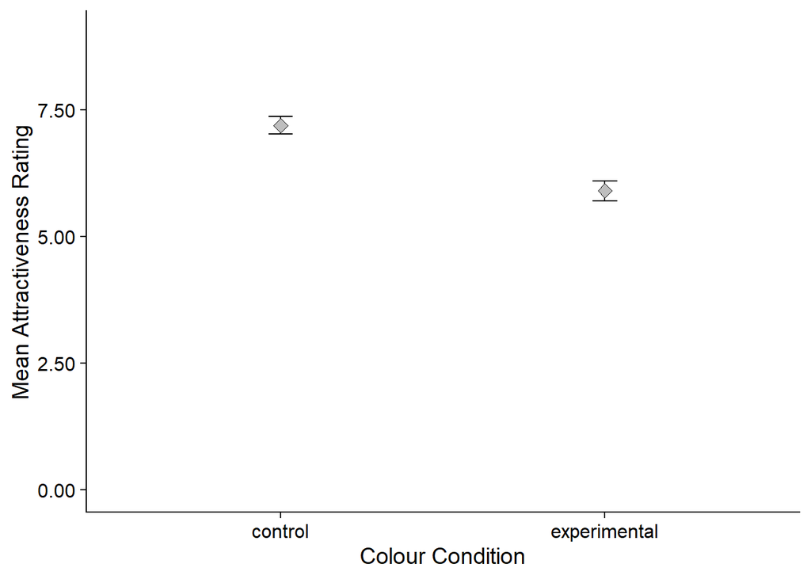

**Figure 1.** *Mean attractiveness rating by colour condition (±1 SEM).*

# Discussion

Our results suggest that viewing a target male in conjunction with the colour red makes him less attractive to the viewer than if he were to be viewed in conjunction with the colour white.

These findings directly conflict with our hypothesis that a photograph of a target male would be rated as more highly attractive when viewed in conjunction with the colour red, rather than the colour white. Our findings also conflict with the results of the original experiment conducted by Elliot et al. (2010), which found that the colour red significantly increased the mean attractiveness rating of a target male. This brings into question the validity of the original experiment and the true nature of the ‘Red Effect’.

Francis (2013) provides insight into possible reasons why the original set of experiments studying the ‘Red Effect’ (Elliot et al., 2010) may be lacking in validity. 12 experiments were reported in the paper, and all 12 findings conclusively rejected the null hypothesis (Elliot et al., 2010). Francis (2013) questions the validity of these results by pointing out that “given the power of the experiments, the probability that the observed 12 findings would all reject the null hypothesis is only .005”. He then brings forth the 0.1 probability threshold that is used to test for publication bias (Begg & Mazumdar, 1994; Ioannidis & Trikalinos, 2007; Sterne, Gavaghan, & Egger, 2000) to claim evidence of publication bias in Elliot et al.’s (2010) work. On the basis of this evidence, Francis (2013) claims that the findings of Elliot et al. (2010) should be considered “non-scientific or anecdotal”.

However, this should not necessarily lead us to conclude that the ‘red effect’ does not exist. As Francis (2013) pointed out in an attempt to criticise the original experiments; given the power of the red effect found in Elliot et al. (2010), the probability that every sample tested will lead to a rejection of the null hypothesis is very low – even if the effect is real. If the findings of Elliot et al. (2010) regarding the power of the ‘Red Effect’ are correct, it should be expected that some studies will find no significant positive effect of red on perceived attractiveness. Thus, we cannot make any conclusive statements about the existence of the ‘Red Effect’ based on the results of a single experiment.

Our participants’ ratings of the target male’s attractiveness came exclusively from the viewing of a single photograph of the target male, for a duration of 5 seconds. This is an obvious limitation of the experiment and it could be argued that the experiment consequently lacks ecological validity, as this scenario does not reflect the circumstances in which real life attractiveness judgements are made. However, we retort that with the prevalence of social media, fast-paced online advertising and photo-based dating technology in today’s society, the conditions presented in our experiment are in fact reflective of the circumstances in which many real-world attractiveness judgements are now made. For this reason, the results may be more relevant than ever.

Like the original experiment (Elliot et al., 2010) our study is limited in that it examines only the attractiveness perceptions of heterosexual females judging a male. In order to widen our understanding of the red effect, future research might consider examining the effect of red on the attractiveness perceptions of homosexual men and women judging members of their own sex.

Our finding, that being viewed in conjunction with the colour red has a negative effect on the perceived attractiveness of a target male, is not reflected in the many previous studies and replications of the original red-attractiveness experiment (Elliot et al., 2010; Elliott & Maier, 2013; Hesslinger, Goldbach & Carbon, 2015; Peperkoorn, Roberts, & Pollet, 2016). We therefore deem it unlikely that the results from our experiment reflect a true negative effect of the colour red on perceived attractiveness. However, the fact that our results contradict the previous research does highlight the need for further study and, in particular, meta-analytic review of the totality of the literature, in order for conclusive statements to be made about the existence of a real ‘Red Effect’ on perceived attractiveness.

In summary, our study found that being viewed in conjunction with the colour red had a significant negative effect on the perceived attractiveness of a target male. This effect is opposite in direction to what we hypothesised based on the original study by Elliot et al. (2010). Our results therefore add to a growing body of research finding no significant positive effect of the colour red on perceived attractiveness - highlighting the need for further study into this effect. We have suggested that it may be informative to expand future research to reflect a more diverse population. However, given that the proposed power of the red effect (Elliot et al., 2010) should be expected to produce varying results at the level of individual experiments, we place particular emphasis on the need for meta-analytic review of the pre-existing literature - in order to draw conclusive statements about what the totality of the data suggests about the existence of the effect. Finally, we suggested that the prevalence of the increasingly fast-paced and image-based worlds of social media, online advertising and online dating in today’s society make the question posed in our study more relevant than ever. In this way, we hope to encourage further research into the topic.

# References

Begg, C. B., & Mazumdar, M. (1994). Operating characteristics of a rank correlation test for publication bias. Biometrics, 1088-1101.

Elliot, A. J., Niesta Kayser, D., Greitemeyer, T., Lichtenfeld, S., Gramzow, R. H., Maier, M. A., & Liu, H. (2010). Red, rank, and romance in women viewing men. Journal of Experimental Psychology: General, 139(3), 399.

Elliot, A. J., & Maier, M. A. (2013). The red-attractiveness effect, applying the Ioannidis and Trikalinos (2007b) test, and the broader scientific context: A reply to Francis (2013).

Francis, G. (2013). Publication bias in “Red, rank, and romance in women viewing men,” by Elliot et al.(2010).

Hesslinger, V. M., Goldbach, L., & Carbon, C. C. (2015). Men in red: A reexamination of the red-attractiveness effect. Psychonomic bulletin & review, 22(4), 1142-1148.

Ioannidis, J. P., & Trikalinos, T. A. (2007). An exploratory test for an excess of significant findings. Clinical trials, 4(3), 245-253.

Peperkoorn, L. S., Roberts, S. C., & Pollet, T. V. (2016). Revisiting the red effect on attractiveness and sexual receptivity: No effect of the color red on human mate preferences. Evolutionary Psychology, 14(4), 1474704916673841.

Sterne, J. A., Gavaghan, D., & Egger, M. (2000). Publication and related bias in meta-analysis: power of statistical tests and prevalence in the literature. Journal of clinical epidemiology, 53(11), 1119-1129.